# Today: Introduction to dynamic problems

Tom Ranner

[figure not shown]

# Static vs dynamic problems

Examples so far have focussed on **static** problems that don't change in time:

[figure not shown]

## Static vs dynamic problems

There are many other problems that require models to change in time, that is the models are **dynamic**:

[video not shown]

# Rates of change

Suppose we know that a person is walking at *constant* 3 meters per second (m/s) - what does that mean?

So how far will they travel in:

- $0.1$ seconds?
- $0.01$ seconds?
- $0.001$ seconds?
- $10^{-6}$ seconds?

What does this tell us about speed?

$$ \text{Distance travelled} = \text{speed} \times \text{time} $$ That is, $$ \text{speed} = \dfrac{\text{distance travelled}}{\text{time}} $$

Equivalently, $$ \text{speed} = \dfrac{(\text{distance at end}) - (\text{distance at start})}{\text{time}}. $$

## The derivative as a rate of change

What if the object's speed was not constant? For example, $S(t) = -(t-1.0)(t+0.5)$.

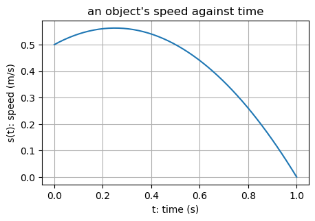

How far would the object travel in one second now? -- with difficulty :(

We could consider each tenth of a second separately and estimate the distance covered at each tenth (assuming the $s$ is approximately constant in each interval):

```python
D, t = 0.0, 0.0
for i in range(10):
    D = D + 0.1 * S(t)
    t = t + 0.1
```

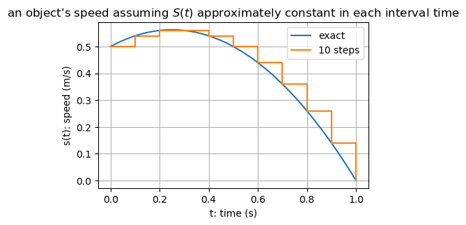

We could consider each hundredth of a second separately and estimate the distance covered at each hundredth (assuming the $s$ is approximately constant in each interval):

```python
D, t = 0.0, 0.0
for i in range(100):
    D = D + 0.01 * S(t)
    t = t + 0.01
```

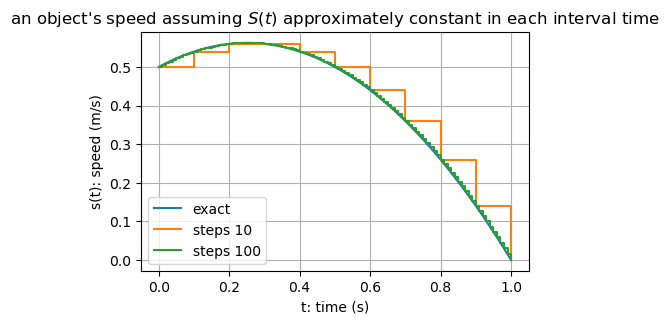

We could consider each thousandth of a second separately and estimate the distance covered at each thousandth (assuming the $s$ is approximately constant in each interval):

```python
D, t = 0.0, 0.0
for i in range(1000):
    D = D + 0.001 * S(t)
    t = t + 0.001
```

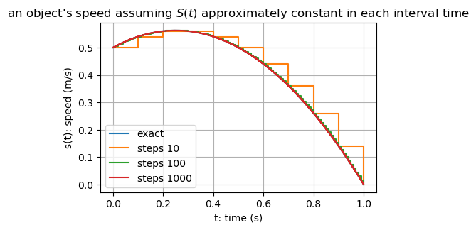

### What values do we get?

Total distance as a function of number of steps

|  | # intervals | increment size dt | total distance |
| --- | --- | --- | --- |
| 0 | 10 | 0.100000 | 0.440000 |
| 1 | 100 | 0.010000 | 0.419150 |
| 2 | 1000 | 0.001000 | 0.416916 |
| 3 | 10000 | 0.000100 | 0.416692 |
| 4 | 100000 | 0.000010 | 0.416669 |

... we appear to be converging to an answer in the limit as $\mathrm{d}t \to 0$...

## So what's going on

At any *instant* of time, the speed is the rate of change in distance:

$$ \text{speed} = \dfrac{\text{change in distance}}{\text{time}} $$

so

$$ \text{change in distance} = \text{time} \times \text{speed} $$

## Mathematically speaking

Call the speed $S(t)$ and distance $D(t)$:

$$ S(t) = \frac{D(t + \mathrm{d}t) - D(t)}{\mathrm{d}t} $$

In fact, to obtain a *converged* answer, we must take smaller and smaller choices for $\mathrm{d}t$:

$$ S(t) = \lim_{\mathrm{d}t \to 0} \frac{D(t + \mathrm{d}t) - D(t)}{\mathrm{d}t} $$

We say that speed, $S(t)$, is the **derivative** of distance, $D(t)$, with respect to time and write $S(t) = D'(t)$.

# A graphical interpretation

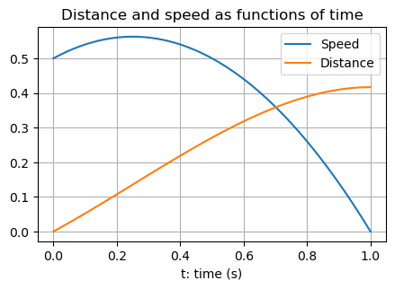

We see the **gradient** (slope) of the orange curve is the **value** of the blue curve.

## The derivative as a gradient

What is the gradient of a line?

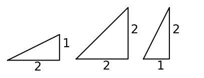

The equation of a straight line with slope $m$ is given by

$$ y(t) = m t + c. $$

### Slope of a curve

What is the gradient of a *curve*?

Well... the gradient of the straight-line approximation (chord) for a small step is

$$ \frac{y(t + \mathrm{d}t) - y(t)}{\mathrm{d}t}. $$

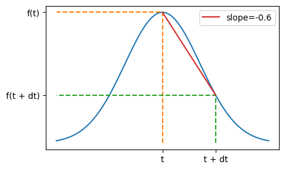

What about reducing $\mathrm{d}t$?

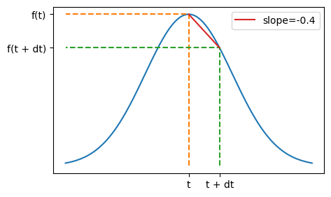

Even more?

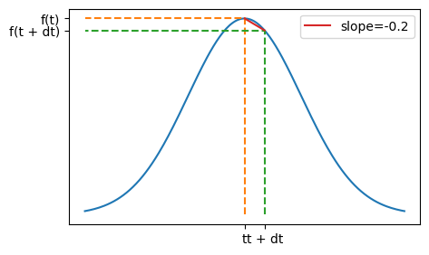

By taking smaller and smaller values of $\mathrm{d}t$, it becomes clear that we can assign an instantaneous value to the slope at any point $t$:

$$ \lim_{\mathrm{d}t \to 0} \frac{y(t+\mathrm{d}t) - y(t)}{\mathrm{d}t}. $$

*But this is precisely the definition of derivative $y'(t)$!*

## Do you feel more confident?

[figure not shown]